# Capstone Project: BellaBeat’s Smart Device Data Analysis

### Analysis

The data analysis will be conducted on each of the datasets following the order of `daily_` and `hourly_`. Now let’s start looking into detail of our data.

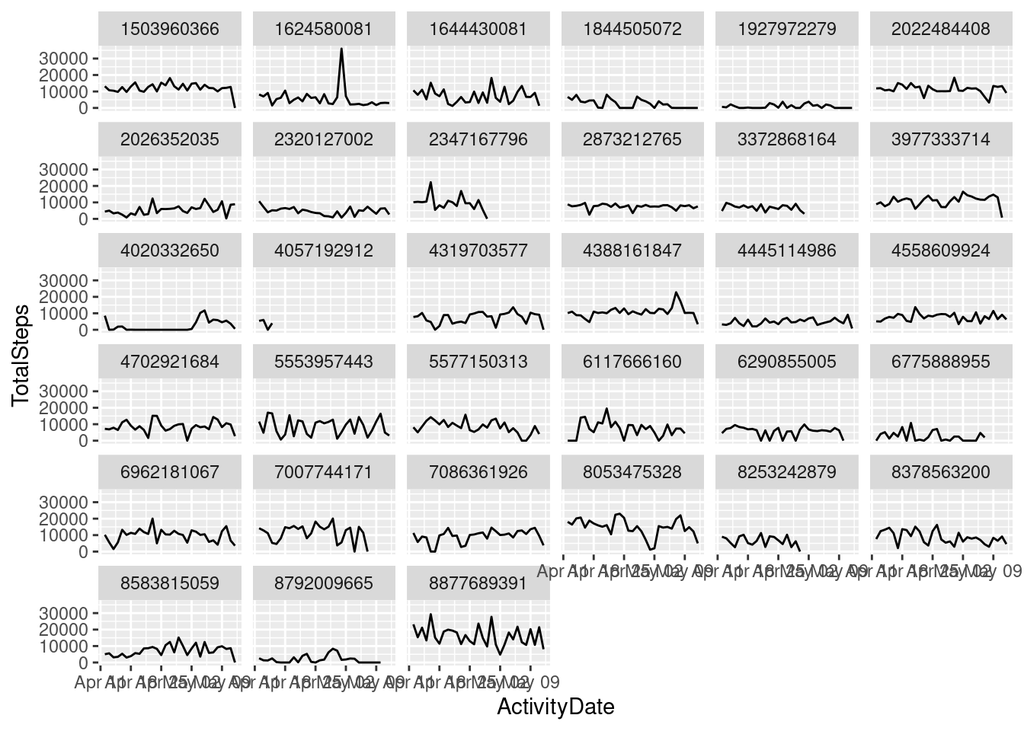

```r
daily_activity_grouped <- daily_activity %>% group_by(Id)

ggplot(daily_activity_grouped, aes(x = ActivityDate, y = TotalSteps)) + geom_line() +
  facet_wrap(~ Id)
```

```r
# It looks like not everyone is exercising daily, so let's go head and find out
# how many of the survey participants are skipping days
record_counts <- daily_activity_grouped %>% summarise(Count = n())
# data from 4-12-2016 to 5-12-2016 is included in the dataset
complete_data_threshold <- 31
half_threshold <- 15
# find the number of participants who do not have complete records
count_below_threshold1 <- sum(record_counts$Count < complete_data_threshold)
count_below_threshold2 <- sum(record_counts$Count < half_threshold)
```

There are in total 33 participants. From the analysis above, 12 of participants didn’t complete the exercise daily and one of them didn’t complete it more than half of the survey period, which is a month.

Examine if there’s any correlation between the quantities listed in the `daily_activity` dataset. As `Calories` often occur as a benchmark for evaluating the results of doing exercises/workout, it’s better for us to examine if `Calories` in this case is correlated with certain quantities:

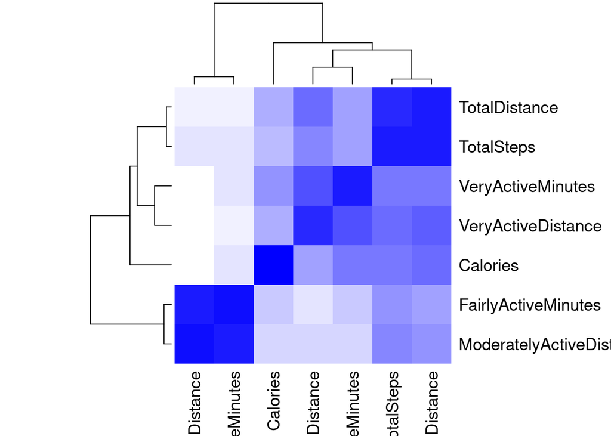

```r
cor_matrix_activity <- daily_activity %>%
  select(TotalDistance,TotalSteps,VeryActiveDistance, VeryActiveMinutes, ModeratelyActiveDistance, FairlyActiveMinutes, Calories) %>%
  mutate_all(as.numeric) %>% cor()
heatmap(cor_matrix_activity,
        col = colorRampPalette(c("white", "blue"))(20),
        margins = c(5, 5))
```

As we’ve already mentioned `Calories` above, let’s go ahead and take a look at our `daily_calories` dataset:

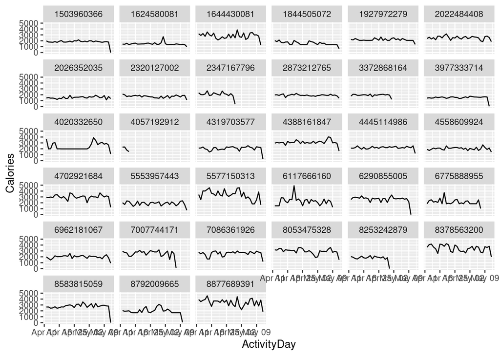

```r
daily_calories_grouped <- daily_calories %>% group_by(Id)
ggplot(daily_calories_grouped, aes(x = ActivityDay, y = Calories)) + geom_line() +
  facet_wrap(~ Id)
```

From the plot, we notice that the majority of user’s daily calories maintain at a stable level with small fluctuations and decreases in the last few days of the reporting period.

Then go to `daily_intensities`:

```r
summary(daily_intensities)
```

```
##        Id             ActivityDay         SedentaryMinutes LightlyActiveMinutes
##  Min.   :1.504e+09   Min.   :2016-04-12   Min.   :   0.0   Min.   :  0.0
##  1st Qu.:2.320e+09   1st Qu.:2016-04-19   1st Qu.: 729.8   1st Qu.:127.0
##  Median :4.445e+09   Median :2016-04-26   Median :1057.5   Median :199.0
##  Mean   :4.855e+09   Mean   :2016-04-26   Mean   : 991.2   Mean   :192.8
##  3rd Qu.:6.962e+09   3rd Qu.:2016-05-04   3rd Qu.:1229.5   3rd Qu.:264.0
##  Max.   :8.878e+09   Max.   :2016-05-12   Max.   :1440.0   Max.   :518.0
##  FairlyActiveMinutes VeryActiveMinutes SedentaryActiveDistance
##  Min.   :  0.00      Min.   :  0.00    Min.   :0.000000
##  1st Qu.:  0.00      1st Qu.:  0.00    1st Qu.:0.000000
##  Median :  6.00      Median :  4.00    Median :0.000000
##  Mean   : 13.56      Mean   : 21.16    Mean   :0.001606
##  3rd Qu.: 19.00      3rd Qu.: 32.00    3rd Qu.:0.000000
##  Max.   :143.00      Max.   :210.00    Max.   :0.110000
##  LightActiveDistance ModeratelyActiveDistance VeryActiveDistance
##  Min.   : 0.000      Min.   :0.0000           Min.   : 0.000
##  1st Qu.: 1.945      1st Qu.:0.0000           1st Qu.: 0.000
##  Median : 3.365      Median :0.2400           Median : 0.210
##  Mean   : 3.341      Mean   :0.5675           Mean   : 1.503
##  3rd Qu.: 4.782      3rd Qu.:0.8000           3rd Qu.: 2.053
##  Max.   :10.710      Max.   :6.4800           Max.   :21.920
```

Let’s take a closer look each single day and start analyzing our `hourly_` datasets. Since the hourly datasets list data measured in every hour of every day in the survey period, it’s easier for us to get an idea out of it by calculating the summary statistics across this period before going to the next step.

```r
hourly_calories_grouped <- hourly_calories %>% group_by(Time) %>%
  summarise(average_calories = mean(Calories))

hourly_intensities_grouped <- hourly_intensities %>% group_by(Time) %>%
  summarise(average_intensity = mean(TotalIntensity))

hourly_steps_grouped <- hourly_steps %>% group_by(Time) %>%
  summarise(average_step = mean(StepTotal))
```

Now that we have the averages of a few hourly measurements distributed across 24 hours of a day, we can make parallel comparisons for these measurements in an ‘average’ day.

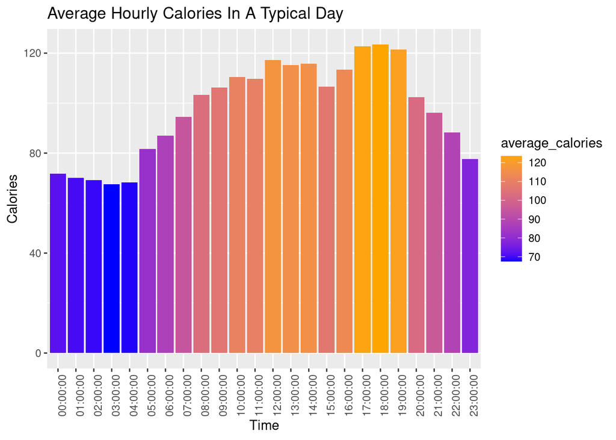

```r
ggplot(data = hourly_calories_grouped) +
  geom_col(mapping = aes(x = Time, y = average_calories, fill = average_calories)) +
  scale_fill_gradient(low = "blue", high = "orange") +
  labs(title = "Average Hourly Calories In A Typical Day", x = "Time", y = "Calories") +
  theme(axis.text.x = element_text(angle = 90))
```

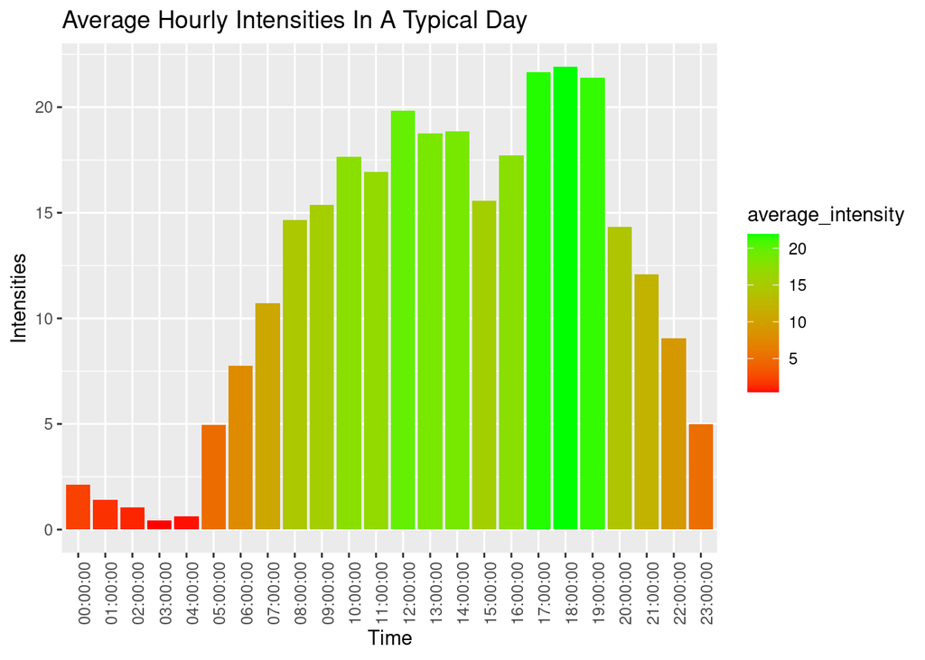

```r
ggplot(data = hourly_intensities_grouped) +
  geom_col(mapping = aes(x = Time, y = average_intensity, fill = average_intensity)) +
  scale_fill_gradient(low = "red", high = "green") +
  labs(title = "Average Hourly Intensities In A Typical Day", x = "Time", y = "Intensities") +
  theme(axis.text.x = element_text(angle = 90))
```

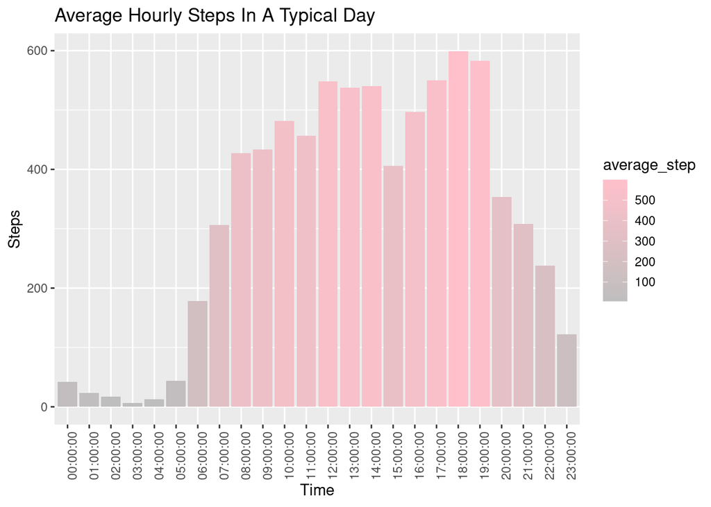

```r
ggplot(data = hourly_steps_grouped) +
  geom_col(mapping = aes(x = Time, y = average_step, fill = average_step)) +
  scale_fill_gradient(low = "grey", high = "pink") +
  labs(title = "Average Hourly Steps In A Typical Day", x = "Time", y = "Steps") +
  theme(axis.text.x = element_text(angle = 90))
```

After observing the above 3 histograms, we can derive the time intervals of two peaks of the three quantities (calories, intensities, and steps) in a typical day: 11:30 - 14:00 and 16:30 - 19:00.